# BhavCopy

This file is meant to be used in conjunction with an article posted on http://www.diyd2.in

1. Download the zip files containing bhav data from http://www.nseindia.com (historical data)
2. Unzip the contents into some folder - you will need to edit the below code to load the csv files
3. Load the csv files from given directory
4. For given symbol, load and plot the close prices by time stamp

Let us define a function that loads and merges all CSV files in a given folder

```r
load_csvs <- function(path) {
  files <- dir(path, pattern = '\\.csv$', full.names = TRUE)
  tables <- lapply(files, read.csv)
  do.call(rbind, tables)
}
```

Since the dates are being parsed as a string, add a new date column from existing column.

```r
basedir <- '~/bhav'
bhavdata <- load_csvs(basedir)
# sapply(bhavdata, class)
bhavdata['TS_DATE'] <- NA
bhavdata['TS_DATE'] <- as.Date(bhavdata$TIMESTAMP, "%d-%b-%Y")
```

Now, try plotting a line chart with the given details..

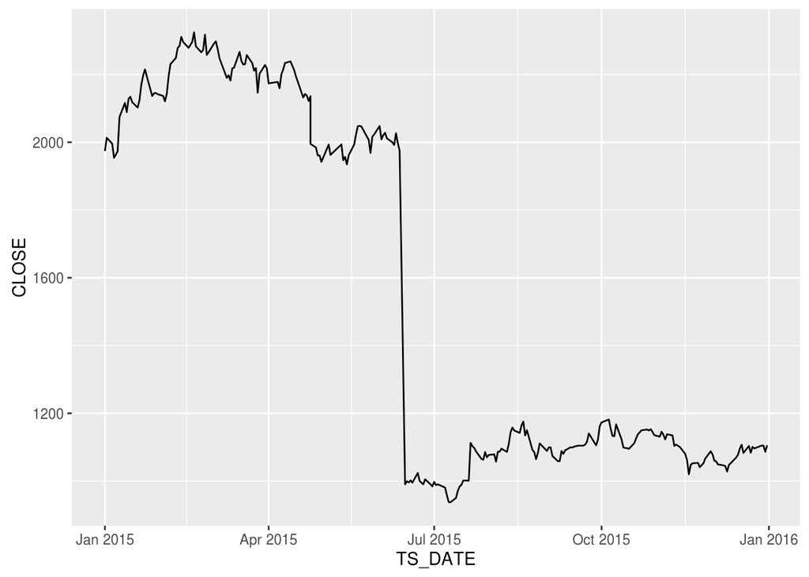

```r
symb <- 'INFY'

require(ggplot2)
df <- bhavdata[bhavdata$SYMBOL == symb,]
ggplot( data = df, aes( TS_DATE, CLOSE )) + geom_line()
```

You will notice the dramatic drop in share price sometime in June. It turns out that the INFY has announced a 1:1 bonus issue and the stock was being quoted ex-bonus from June-15th, 2015 onwards.

Doing a candle chart seems to be a bit more harder. I have hardcoded some things to make it work.

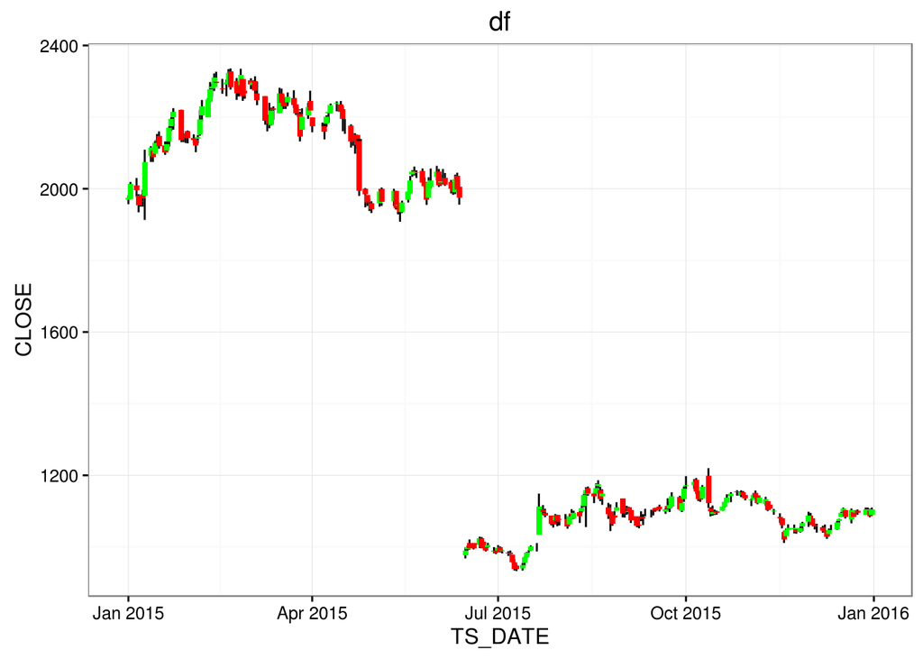

```r
df$chg <- ifelse(df$CLOSE > df$OPEN, "UP", "DN")
df$width <- 3
df$no_change <- df[, "HIGH"] == df[, "LOW"]

# Candle chart
pl <- ggplot(df, aes(x=TS_DATE))+
  geom_linerange(aes(ymin=LOW, ymax=HIGH)) +
  theme_bw() +
  labs(title="df") +
  geom_rect(
    aes(xmin = TS_DATE - width/2 * 0.9, xmax = TS_DATE + width/2 * 0.9,
        ymin = pmin(OPEN, CLOSE), ymax = pmax(OPEN, CLOSE), fill = chg)
    ) + guides(fill = FALSE, colour = FALSE) + scale_fill_manual(values = c("DN" = "red", "UP" = "green"))

# When OPEN and CLOSE are same ...
if (any(df$no_change)) pl <- pl + geom_segment(data = df[df$no_change,], aes(x = TS_DATE - width / 2 * 0.9, y = CLOSE, yend = CLOSE, xend = TS_DATE + width / 2 * 0.9))

print(pl)
```